# Sesión 8: Minería de texto

Jacob Muñoz | ML-IA (Adaptedo del código de Ken Benoit y del material de curso de Kevin Munger)

# Preliminares: instalación

Primero, necesita tener **quanteda** instalado. Puede hacerlo desde RStudio, del menú Tools…Install Packages, o simplemente usando

```r
install.packages("quanteda")
```

(Opcional) Puede instalar corpus data adicional de **quantedaData** usando

```r
## the devtools package is required to install quanteda from Github
devtools::install_github("quanteda/quanteda.corpora")
```

En **Windows platforms**, es recomendado que instale [RTools suite](https://cran.r-project.org/bin/windows/Rtools/), y para **OS X**, que instale [XCode](https://itunes.apple.com/gb/app/xcode/id497799835?mt=12) del App Store.

#### Probemos el setup

```r
require(quanteda)
summary(data_corpus_inaugural)
## Corpus consisting of 58 documents, showing 58 documents:
##
##             Text Types Tokens Sentences Year  President       FirstName
##  1789-Washington   625   1537        23 1789 Washington          George
##  1793-Washington    96    147         4 1793 Washington          George
##       1797-Adams   826   2577        37 1797      Adams            John
##   1801-Jefferson   717   1923        41 1801  Jefferson          Thomas
##   1805-Jefferson   804   2380        45 1805  Jefferson          Thomas
##     1809-Madison   535   1261        21 1809    Madison           James
##     1813-Madison   541   1302        33 1813    Madison           James
##      1817-Monroe  1040   3677       121 1817     Monroe           James
##      1821-Monroe  1259   4886       131 1821     Monroe           James
##       1825-Adams  1003   3147        74 1825      Adams     John Quincy
##     1829-Jackson   517   1208        25 1829    Jackson          Andrew
##     1833-Jackson   499   1267        29 1833    Jackson          Andrew
##    1837-VanBuren  1315   4158        95 1837  Van Buren          Martin
##    1841-Harrison  1898   9123       210 1841   Harrison   William Henry
##        1845-Polk  1334   5186       153 1845       Polk      James Knox
##      1849-Taylor   496   1178        22 1849     Taylor         Zachary
##      1853-Pierce  1165   3636       104 1853     Pierce        Franklin
##    1857-Buchanan   945   3083        89 1857   Buchanan           James
##     1861-Lincoln  1075   3999       135 1861    Lincoln         Abraham
##     1865-Lincoln   360    775        26 1865    Lincoln         Abraham
##       1869-Grant   485   1229        40 1869      Grant      Ulysses S.
##       1873-Grant   552   1472        43 1873      Grant      Ulysses S.
##       1877-Hayes   831   2707        59 1877      Hayes   Rutherford B.
##    1881-Garfield  1021   3209       111 1881   Garfield        James A.
##   1885-Cleveland   676   1816        44 1885  Cleveland          Grover
##    1889-Harrison  1352   4721       157 1889   Harrison        Benjamin
##   1893-Cleveland   821   2125        58 1893  Cleveland          Grover
##    1897-McKinley  1232   4353       130 1897   McKinley         William
##    1901-McKinley   854   2437       100 1901   McKinley         William
##   1905-Roosevelt   404   1079        33 1905  Roosevelt        Theodore
##        1909-Taft  1437   5821       158 1909       Taft  William Howard
##      1913-Wilson   658   1882        68 1913     Wilson         Woodrow
##      1917-Wilson   549   1652        59 1917     Wilson         Woodrow
##     1921-Harding  1169   3719       148 1921    Harding       Warren G.
##    1925-Coolidge  1220   4440       196 1925   Coolidge          Calvin
##      1929-Hoover  1090   3860       158 1929     Hoover         Herbert
##   1933-Roosevelt   743   2057        85 1933  Roosevelt     Franklin D.
##   1937-Roosevelt   725   1989        96 1937  Roosevelt     Franklin D.
##   1941-Roosevelt   526   1519        68 1941  Roosevelt     Franklin D.
##   1945-Roosevelt   275    633        27 1945  Roosevelt     Franklin D.
##      1949-Truman   781   2504       116 1949     Truman        Harry S.
##  1953-Eisenhower   900   2743       119 1953 Eisenhower       Dwight D.
##  1957-Eisenhower   621   1907        92 1957 Eisenhower       Dwight D.
##     1961-Kennedy   566   1541        52 1961    Kennedy         John F.
##     1965-Johnson   568   1710        93 1965    Johnson   Lyndon Baines
##       1969-Nixon   743   2416       103 1969      Nixon Richard Milhous
##       1973-Nixon   544   1995        68 1973      Nixon Richard Milhous
##      1977-Carter   527   1369        52 1977     Carter           Jimmy
##      1981-Reagan   902   2780       129 1981     Reagan          Ronald
##      1985-Reagan   925   2909       123 1985     Reagan          Ronald
##        1989-Bush   795   2673       141 1989       Bush          George
##     1993-Clinton   642   1833        81 1993    Clinton            Bill
##     1997-Clinton   773   2436       111 1997    Clinton            Bill
##        2001-Bush   621   1806        97 2001       Bush       George W.
##        2005-Bush   772   2312        99 2005       Bush       George W.
##       2009-Obama   938   2689       110 2009      Obama          Barack
##       2013-Obama   814   2317        88 2013      Obama          Barack
##       2017-Trump   582   1660        88 2017      Trump       Donald J.
##                  Party
##                   none
##                   none
##             Federalist
##  Democratic-Republican
##  Democratic-Republican
##  Democratic-Republican
##  Democratic-Republican
##  Democratic-Republican
##  Democratic-Republican
##  Democratic-Republican
##             Democratic
##             Democratic
##             Democratic
##                   Whig
##                   Whig
##                   Whig
##             Democratic
##             Democratic
##             Republican
##             Republican
##             Republican
##             Republican
##             Republican
##             Republican
##             Democratic
##             Republican
##             Democratic
##             Republican
##             Republican
##             Republican
##             Republican
##             Democratic
##             Democratic
##             Republican
##             Republican
##             Republican
##             Democratic
##             Democratic
##             Democratic
##             Democratic
##             Democratic
##             Republican
##             Republican
##             Democratic
##             Democratic
##             Republican
##             Republican
##             Democratic
##             Republican
##             Republican
##             Republican
##             Democratic
##             Democratic
##             Republican
##             Republican
##             Democratic
##             Democratic
##             Republican
```

Creemos una matriz documento-atributo a partir del corpus, removiendo stop words:

```r
ieDfm <- dfm(
  data_corpus_inaugural,
  remove = c(stopwords("english"), "God", "Bless", "America"),
  stem = TRUE)
```

Echemos un vistazo a los atributos más recurrentes:

```r
topfeatures(ieDfm)
```

```
##      ,      . nation govern  peopl      ;     us    can  state      -
##   7026   4945    675    657    623    565    478    471    450    394
```

Una forma de graficar esto es en una nube de palabras:

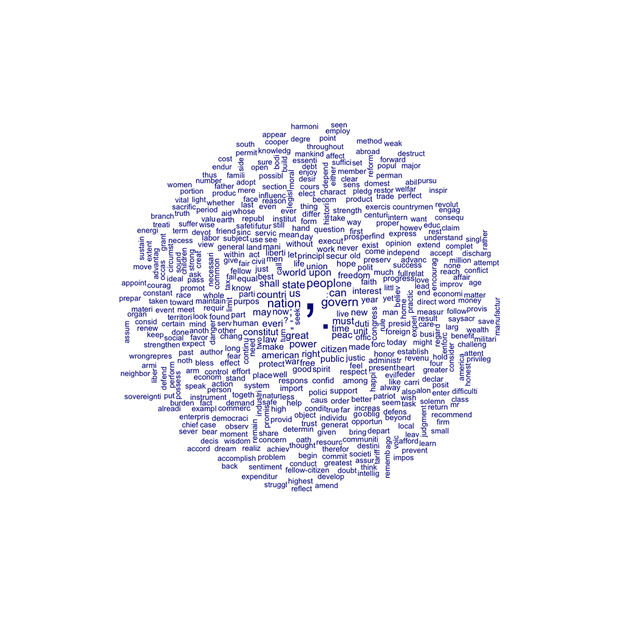

```r
textplot_wordcloud(ieDfm, min_count = 25, random_order = FALSE)
```

# Introducción y flujo de trabajo

Esta sección demuestra un workflow básico para tomar algunos textos preparados y realizar tareas básicas de análisis de texto. El paquete `quanteda` viene con un conjunto de discursos presidenciales. Empezamos por examinar estos textos. La función `summary` devuelve el nombre de cada texto junto con el número de types, tokens y oraciones contenidas en el texto. Abajo usamos la sintaxis de indexación de R para selectivamente usar la función summary en los primeros cinco textos.

```r
summary(data_corpus_inaugural)
## Corpus consisting of 58 documents, showing 58 documents:
##
##             Text Types Tokens Sentences Year  President       FirstName
##  1789-Washington   625   1537        23 1789 Washington          George
##  1793-Washington    96    147         4 1793 Washington          George
##       1797-Adams   826   2577        37 1797      Adams            John
##   1801-Jefferson   717   1923        41 1801  Jefferson          Thomas
##   1805-Jefferson   804   2380        45 1805  Jefferson          Thomas
##     1809-Madison   535   1261        21 1809    Madison           James
##     1813-Madison   541   1302        33 1813    Madison           James
##      1817-Monroe  1040   3677       121 1817     Monroe           James
##      1821-Monroe  1259   4886       131 1821     Monroe           James
##       1825-Adams  1003   3147        74 1825      Adams     John Quincy
##     1829-Jackson   517   1208        25 1829    Jackson          Andrew
##     1833-Jackson   499   1267        29 1833    Jackson          Andrew
##    1837-VanBuren  1315   4158        95 1837  Van Buren          Martin
##    1841-Harrison  1898   9123       210 1841   Harrison   William Henry
##        1845-Polk  1334   5186       153 1845       Polk      James Knox
##      1849-Taylor   496   1178        22 1849     Taylor         Zachary
##      1853-Pierce  1165   3636       104 1853     Pierce        Franklin
##    1857-Buchanan   945   3083        89 1857   Buchanan           James
##     1861-Lincoln  1075   3999       135 1861    Lincoln         Abraham
##     1865-Lincoln   360    775        26 1865    Lincoln         Abraham
##       1869-Grant   485   1229        40 1869      Grant      Ulysses S.
##       1873-Grant   552   1472        43 1873      Grant      Ulysses S.
##       1877-Hayes   831   2707        59 1877      Hayes   Rutherford B.
##    1881-Garfield  1021   3209       111 1881   Garfield        James A.
##   1885-Cleveland   676   1816        44 1885  Cleveland          Grover
##    1889-Harrison  1352   4721       157 1889   Harrison        Benjamin
##   1893-Cleveland   821   2125        58 1893  Cleveland          Grover
##    1897-McKinley  1232   4353       130 1897   McKinley         William
##    1901-McKinley   854   2437       100 1901   McKinley         William
##   1905-Roosevelt   404   1079        33 1905  Roosevelt        Theodore
##        1909-Taft  1437   5821       158 1909       Taft  William Howard
##      1913-Wilson   658   1882        68 1913     Wilson         Woodrow
##      1917-Wilson   549   1652        59 1917     Wilson         Woodrow
##     1921-Harding  1169   3719       148 1921    Harding       Warren G.
##    1925-Coolidge  1220   4440       196 1925   Coolidge          Calvin
##      1929-Hoover  1090   3860       158 1929     Hoover         Herbert
##   1933-Roosevelt   743   2057        85 1933  Roosevelt     Franklin D.
##   1937-Roosevelt   725   1989        96 1937  Roosevelt     Franklin D.
##   1941-Roosevelt   526   1519        68 1941  Roosevelt     Franklin D.
##   1945-Roosevelt   275    633        27 1945  Roosevelt     Franklin D.
##      1949-Truman   781   2504       116 1949     Truman        Harry S.
##  1953-Eisenhower   900   2743       119 1953 Eisenhower       Dwight D.
##  1957-Eisenhower   621   1907        92 1957 Eisenhower       Dwight D.
##     1961-Kennedy   566   1541        52 1961    Kennedy         John F.
##     1965-Johnson   568   1710        93 1965    Johnson   Lyndon Baines
##       1969-Nixon   743   2416       103 1969      Nixon Richard Milhous
##       1973-Nixon   544   1995        68 1973      Nixon Richard Milhous
##      1977-Carter   527   1369        52 1977     Carter           Jimmy
##      1981-Reagan   902   2780       129 1981     Reagan          Ronald
##      1985-Reagan   925   2909       123 1985     Reagan          Ronald
##        1989-Bush   795   2673       141 1989       Bush          George
##     1993-Clinton   642   1833        81 1993    Clinton            Bill
##     1997-Clinton   773   2436       111 1997    Clinton            Bill
##        2001-Bush   621   1806        97 2001       Bush       George W.
##        2005-Bush   772   2312        99 2005       Bush       George W.
##       2009-Obama   938   2689       110 2009      Obama          Barack
##       2013-Obama   814   2317        88 2013      Obama          Barack
##       2017-Trump   582   1660        88 2017      Trump       Donald J.
##                  Party
##                   none
##                   none
##             Federalist
##  Democratic-Republican
##  Democratic-Republican
##  Democratic-Republican
##  Democratic-Republican
##  Democratic-Republican
##  Democratic-Republican
##  Democratic-Republican
##             Democratic
##             Democratic
##             Democratic
##                   Whig
##                   Whig
##                   Whig
##             Democratic
##             Democratic
##             Republican
##             Republican
##             Republican
##             Republican
##             Republican
##             Republican
##             Democratic
##             Republican
##             Democratic
##             Republican
##             Republican
##             Republican
##             Republican
##             Democratic
##             Democratic
##             Republican
##             Republican
##             Republican
##             Democratic
##             Democratic
##             Democratic
##             Democratic
##             Democratic
##             Republican
##             Republican
##             Democratic
##             Democratic
##             Republican
##             Republican
##             Democratic
##             Republican
##             Republican
##             Republican
##             Democratic
##             Democratic
##             Republican
##             Republican
##             Democratic
##             Democratic
##             Republican
summary(data_corpus_inaugural[1:5])
## Corpus consisting of 5 documents, showing 5 documents:
##
##             Text Types Tokens Sentences Year  President FirstName
##  1789-Washington   625   1537        23 1789 Washington    George
##  1793-Washington    96    147         4 1793 Washington    George
##       1797-Adams   826   2577        37 1797      Adams      John
##   1801-Jefferson   717   1923        41 1801  Jefferson    Thomas
##   1805-Jefferson   804   2380        45 1805  Jefferson    Thomas
##                  Party
##                   none
##                   none
##             Federalist
##  Democratic-Republican
##  Democratic-Republican

data_corpus_inaugural[1]
## Corpus consisting of 1 document and 4 docvars.
## 1789-Washington :
## "Fellow-Citizens of the Senate and of the House of Representa..."
cat(data_corpus_inaugural[2])
## Fellow citizens, I am again called upon by the voice of my country to execute the functions of its Chief Magistrate. When the occasion proper for it shall arrive, I shall endeavor to express the high sense I entertain of this distinguished honor, and of the confidence which has been reposed in me by the people of united America.
##
## Previous to the execution of any official act of the President the Constitution requires an oath of office. This oath I am now about to take, and in your presence: That if it shall be found during my administration of the Government I have in any instance violated willingly or knowingly the injunctions thereof, I may (besides incurring constitutional punishment) be subject to the upbraidings of all who are now witnesses of the present solemn ceremony.
##
##

ndoc(data_corpus_inaugural)
```

```
## [1] 58
```

```r
docnames(data_corpus_inaugural)
```

```
##  [1] "1789-Washington" "1793-Washington" "1797-Adams"      "1801-Jefferson"
##  [5] "1805-Jefferson"  "1809-Madison"    "1813-Madison"    "1817-Monroe"
##  [9] "1821-Monroe"     "1825-Adams"      "1829-Jackson"    "1833-Jackson"
## [13] "1837-VanBuren"   "1841-Harrison"   "1845-Polk"       "1849-Taylor"
## [17] "1853-Pierce"     "1857-Buchanan"   "1861-Lincoln"    "1865-Lincoln"
## [21] "1869-Grant"      "1873-Grant"      "1877-Hayes"      "1881-Garfield"
## [25] "1885-Cleveland"  "1889-Harrison"   "1893-Cleveland"  "1897-McKinley"
## [29] "1901-McKinley"   "1905-Roosevelt"  "1909-Taft"       "1913-Wilson"
## [33] "1917-Wilson"     "1921-Harding"    "1925-Coolidge"   "1929-Hoover"
## [37] "1933-Roosevelt"  "1937-Roosevelt"  "1941-Roosevelt"  "1945-Roosevelt"
## [41] "1949-Truman"     "1953-Eisenhower" "1957-Eisenhower" "1961-Kennedy"
## [45] "1965-Johnson"    "1969-Nixon"      "1973-Nixon"      "1977-Carter"
## [49] "1981-Reagan"     "1985-Reagan"     "1989-Bush"       "1993-Clinton"
## [53] "1997-Clinton"    "2001-Bush"       "2005-Bush"       "2009-Obama"
## [57] "2013-Obama"      "2017-Trump"
```

```r
nchar(data_corpus_inaugural[1:7])
## 1789-Washington 1793-Washington      1797-Adams  1801-Jefferson  1805-Jefferson
##            8619             790           13877           10140           12908
##    1809-Madison    1813-Madison
##            7002            7156
ntoken(data_corpus_inaugural[1:7])
## 1789-Washington 1793-Washington      1797-Adams  1801-Jefferson  1805-Jefferson
##            1537             147            2577            1923            2380
##    1809-Madison    1813-Madison
##            1261            1302
ntoken(data_corpus_inaugural[1:7], remove_punct = TRUE)
## 1789-Washington 1793-Washington      1797-Adams  1801-Jefferson  1805-Jefferson
##            1430             135            2318            1726            2166
##    1809-Madison    1813-Madison
##            1175            1210
ntype(data_corpus_inaugural[1:7])
## 1789-Washington 1793-Washington      1797-Adams  1801-Jefferson  1805-Jefferson
##             625              96             826             717             804
##    1809-Madison    1813-Madison
##             535             541
```

Una de las tareas de análisis de texto más fundamentales es la tokenización. Tokenizar un texto es dividirlo en unidades, más comúnmente palabras, que se pueden contar y formar la base de un análisis cuantitativo. El paquete quanteda tiene una función de tokenización: `tokens`, que construye un objeto de tokens **quanteda** que consiste en los textos segmentados por sus términos (y por defecto, otros elementos como puntuación, números, símbolos, etc.). Examine la página del manual en `? Tokens` para obtener detalles sobre esta función:

```r
?tokens
```

La función `tokens` de **quanteda** se puede utilizar en un vector de caracteres simple, un vector de vectores de caracteres o un corpus. Aquí hay unos ejemplos:

```r
tokens("Today is Thursday in Canberra. It is yesterday in London.")
## Tokens consisting of 1 document.
## text1 :
##  [1] "Today"     "is"        "Thursday"  "in"        "Canberra"  "."
##  [7] "It"        "is"        "yesterday" "in"        "London"    "."

vec <- c(one = "This is text one",
         two = "This, however, is the second text")
tokens(vec)
## Tokens consisting of 2 documents.
## one :
## [1] "This" "is"   "text" "one"
##
## two :
## [1] "This"    ","       "however" ","       "is"      "the"     "second"
## [8] "text"
```

Considere los argumentos predeterminados para la función `tokens ()`. Para eliminar la puntuación, debes establecer el argumento `remove_punct` en`TRUE`. Podemos combinar esto con la función `char_tolower ()` para obtener una versión limpia y tokenizada de nuestro texto.

```r
tokens(char_tolower(vec), remove_punct = TRUE)
## Tokens consisting of 2 documents.
## one :
## [1] "this" "is"   "text" "one"
##
## two :
## [1] "this"    "however" "is"      "the"     "second"  "text"
```

La forma en que se nombra `char_tolower()` refleja la [lógica de la gramática de funciones de **quanteda**](http://quanteda.io/articles/pkgdown_only/design.html) . La primera parte (antes del guión bajo `_`) nombra las dos clases de objeto que se ingresan a la función y que la función devuelve. Para poner en minúscula un objeto de clase R `character`, por ejemplo, usa`char_tolower ()`, y para poner en minúscula un objeto de clase **quanteda**`tokens`, usa `tokens_tolower ()`. Algunas clases de objetos se definen en la base R, y otras se han definido mediante paquetes que amplían la funcionalidad de R (**quanteda** es un ejemplo; hay más de 10,000 paquetes contribuidos solo en el archivo CRAN. CRAN significa Red Completa de Archivos R y es donde se publica el paquete **quanteda**).

Usando esta función con las direcciones inaugurales:

```r
inaugTokens <- tokens(data_corpus_inaugural, remove_punct = TRUE)
tokens_tolower(inaugTokens[2])
## Tokens consisting of 1 document and 4 docvars.
## 1793-Washington :
##  [1] "fellow"   "citizens" "i"        "am"       "again"    "called"
##  [7] "upon"     "by"       "the"      "voice"    "of"       "my"
## [ ... and 123 more ]
```

Aquí, proporcionamos uno de los *argumentos* opcionales a la función `tokens ()`: `remove_punct`. Esta función toma un [valor de tipo “lógico”](https://stat.ethz.ch/R-manual/R-devel/library/base/html/logical.html) (`TRUE` o`FALSE`) y especifica si los caracteres de puntuación deben eliminarse o no. La página de ayuda para `tokens ()`, a la que puede acceder usando el comando `?tokens`, detalla todos los argumentos de la función y sus valores válidos.

Cada función en R y sus paquetes contribuidos tiene una página de ayuda, y este es el primer lugar para buscar al examinar una función. Las páginas de ayuda bien redactadas también contienen ejemplos que puede ejecutar para ver cómo funciona una función. Para **quanteda**, las funciones principales también tienen páginas de ayuda con los resultados de ejecutar sus ejemplos en http://quanteda.io/reference/.

Volviendo a la tokenización: Una vez que cada texto se ha dividido en palabras, podemos usar la función `dfm` para crear una matriz de recuentos de las ocurrencias de cada palabra en cada documento:

```r
inaugDfm <- dfm(inaugTokens)
trimmedInaugDfm <- dfm_trim(inaugDfm, min_doc = 5, min_count = 10)
weightedTrimmedDfm <- dfm_tfidf(trimmedInaugDfm)

require(magrittr)
inaugDfm2 <- dfm(inaugTokens) %>%
    dfm_trim(min_doc = 5, min_count = 10) %>%
        dfm_tfidf()
```

Tenga en cuenta que `dfm ()` funciona en una variedad de tipos de objetos, incluidos vectores de caracteres, objetos de corpus y objetos de texto tokenizados. Esto le da al usuario la máxima flexibilidad y poder, al mismo tiempo que facilita la obtención de resultados similares al pasar directamente de los textos a una matriz de documento por función.

Para ver qué objetos para los que se define cualquier *method* (función) en particular, puede usar la función `methods()`:

```r
methods(dfm)
```

```
## [1] dfm.character* dfm.corpus*    dfm.default*   dfm.dfm*       dfm.tokens*
## see '?methods' for accessing help and source code
```

Del mismo modo, también puede averiguar qué métodos están definidos para cualquier *class* de objeto dada, utilizando la misma función:

```r
methods(class = "tokens")
```

```
##  [1] [                     [[                    [[<-
##  [4] [<-                   +                     $
##  [7] $<-                   as.character          as.list
## [10] as.tokens             c                     dfm
## [13] docnames              docnames<-            docvars
## [16] docvars<-             fcm                   kwic
## [19] lengths               meta                  meta<-
## [22] metadoc               metadoc<-             names<-
## [25] ndoc                  nsentence             nsyllable
## [28] ntoken                ntype                 phrase
## [31] print                 textstat_collocations textstat_lexdiv
## [34] textstat_summary      tokens_chunk          tokens_compound
## [37] tokens_lookup         tokens_ngrams         tokens_replace
## [40] tokens_sample         tokens_segment        tokens_select
## [43] tokens_skipgrams      tokens_split          tokens_subset
## [46] tokens_tolower        tokens_tortl          tokens_toupper
## [49] tokens_wordstem       tokens                types
## [52] unlist
## see '?methods' for accessing help and source code
```

```r
summary(data_corpus_inaugural[52:57])
## Corpus consisting of 6 documents, showing 6 documents:
##
##          Text Types Tokens Sentences Year President FirstName      Party
##  1993-Clinton   642   1833        81 1993   Clinton      Bill Democratic
##  1997-Clinton   773   2436       111 1997   Clinton      Bill Democratic
##     2001-Bush   621   1806        97 2001      Bush George W. Republican
##     2005-Bush   772   2312        99 2005      Bush George W. Republican
##    2009-Obama   938   2689       110 2009     Obama    Barack Democratic
##    2013-Obama   814   2317        88 2013     Obama    Barack Democratic
```

Podemos usar la opción `docvars` del comando`corpus` para registrar la fiesta con la que está asociado cada texto:

```r
dv <- data.frame(Party = c("dem", "dem", "rep", "rep", "dem", "dem"))
recentCorpus <- corpus(data_corpus_inaugural[52:57], docvars = dv)
summary(recentCorpus)
## Corpus consisting of 6 documents, showing 6 documents:
##
##          Text Types Tokens Sentences Party
##  1993-Clinton   642   1833        81   dem
##  1997-Clinton   773   2436       111   dem
##     2001-Bush   621   1806        97   rep
##     2005-Bush   772   2312        99   rep
##    2009-Obama   938   2689       110   dem
##    2013-Obama   814   2317        88   dem
```

Podemos usar estos metadatos para combinar características en todos los documentos al crear una matriz de características de documento:

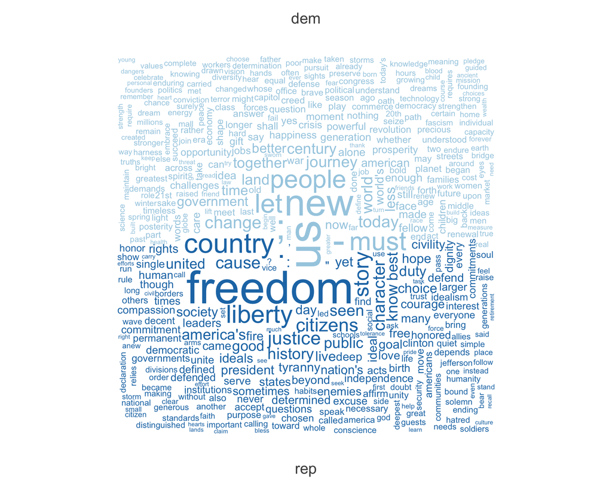

```r
partyDfm <- dfm(recentCorpus, groups = "Party", remove = (stopwords("english")))
textplot_wordcloud(partyDfm, comparison = TRUE)
```

# Manupular texto en R

En esta sección trabajaremos a través de algunas funciones básicas de manipulación de cadenas en R.

## Manejo de cadenas en base R

Hay varias funciones útiles de manipulación de cadenas en la biblioteca base de R. Además, veremos el paquete `stringr` que proporciona una interfaz adicional para la manipulación de texto simple.

El tipo fundamental (o “modo”) en el que R almacena texto es el vector de caracteres. El caso más simple es un vector de caracteres de longitud uno. La función `nchar` devuelve el número de caracteres en un vector de caracteres.

```r
s1 <- 'my example text'
length(s1)
```

```
## [1] 1
```

```r
nchar(s1)
```

```
## [1] 15
```

La función `nchar` está vectorizada, lo que significa que cuando se llama a un vector, devuelve un valor para cada elemento del vector.

```r
s2 <- c('This is', 'my example text.', 'So imaginative.')
length(s2)
```

```
## [1] 3
```

```r
nchar(s2)
```

```
## [1]  7 16 15
```

```r
sum(nchar(s2))
```

```
## [1] 38
```

Podemos usar esto para responder algunas preguntas sencillas sobre los discursos inaugurales.

¿Cuáles fueron los discursos más largos y más cortos?

```r
inaugTexts <- texts(data_corpus_inaugural)
which.max(nchar(inaugTexts))
## 1841-Harrison
##            14
which.min(nchar(inaugTexts))
## 1793-Washington
##               2
```

A diferencia de otros lenguajes de programación, no es posible indexar en una “cadena”, donde una cadena se define como una secuencia de caracteres de texto, en R:

```r
s1 <- 'This file contains many fascinating example sentences.'
s1[6:9]
```

```
## [1] NA NA NA NA
```

Para extraer una subcadena, en su lugar usamos la función `substr`.

```r
s1 <- 'This file contains many fascinating example sentences.'
substr(s1, 6,9)
```

```
## [1] "file"
```

A menudo nos gustaría dividir los vectores de caracteres para extraer un término de interés. Esto es posible usando la función `strsplit`. Considere los nombres de los textos inaugurales:

```r
names(inaugTexts)
```

```
##  [1] "1789-Washington" "1793-Washington" "1797-Adams"      "1801-Jefferson"
##  [5] "1805-Jefferson"  "1809-Madison"    "1813-Madison"    "1817-Monroe"
##  [9] "1821-Monroe"     "1825-Adams"      "1829-Jackson"    "1833-Jackson"
## [13] "1837-VanBuren"   "1841-Harrison"   "1845-Polk"       "1849-Taylor"
## [17] "1853-Pierce"     "1857-Buchanan"   "1861-Lincoln"    "1865-Lincoln"
## [21] "1869-Grant"      "1873-Grant"      "1877-Hayes"      "1881-Garfield"
## [25] "1885-Cleveland"  "1889-Harrison"   "1893-Cleveland"  "1897-McKinley"
## [29] "1901-McKinley"   "1905-Roosevelt"  "1909-Taft"       "1913-Wilson"
## [33] "1917-Wilson"     "1921-Harding"    "1925-Coolidge"   "1929-Hoover"
## [37] "1933-Roosevelt"  "1937-Roosevelt"  "1941-Roosevelt"  "1945-Roosevelt"
## [41] "1949-Truman"     "1953-Eisenhower" "1957-Eisenhower" "1961-Kennedy"
## [45] "1965-Johnson"    "1969-Nixon"      "1973-Nixon"      "1977-Carter"
## [49] "1981-Reagan"     "1985-Reagan"     "1989-Bush"       "1993-Clinton"
## [53] "1997-Clinton"    "2001-Bush"       "2005-Bush"       "2009-Obama"
## [57] "2013-Obama"      "2017-Trump"
```

```r
# returns a list of parts
s1 <- 'split this string'
strsplit(s1, 'this')
## [[1]]
## [1] "split "  " string"
parts <- strsplit(names(inaugTexts), '-')
years <- sapply(parts, function(x) x[1])
pres <-  sapply(parts, function(x) x[2])
```

La función `paste` se utiliza para unir vectores de caracteres. La forma en que se combinan los elementos depende de los valores de los argumentos `sep` y`collapse`:

```r
paste('one', 'two', 'three')
```

```
## [1] "one two three"
```

```r
paste('one', 'two', 'three', sep = '_')
```

```
## [1] "one_two_three"
```

```r
paste(years, pres, sep = '-')
```

```
##  [1] "1789-Washington" "1793-Washington" "1797-Adams"      "1801-Jefferson"
##  [5] "1805-Jefferson"  "1809-Madison"    "1813-Madison"    "1817-Monroe"
##  [9] "1821-Monroe"     "1825-Adams"      "1829-Jackson"    "1833-Jackson"
## [13] "1837-VanBuren"   "1841-Harrison"   "1845-Polk"       "1849-Taylor"
## [17] "1853-Pierce"     "1857-Buchanan"   "1861-Lincoln"    "1865-Lincoln"
## [21] "1869-Grant"      "1873-Grant"      "1877-Hayes"      "1881-Garfield"
## [25] "1885-Cleveland"  "1889-Harrison"   "1893-Cleveland"  "1897-McKinley"
## [29] "1901-McKinley"   "1905-Roosevelt"  "1909-Taft"       "1913-Wilson"
## [33] "1917-Wilson"     "1921-Harding"    "1925-Coolidge"   "1929-Hoover"
## [37] "1933-Roosevelt"  "1937-Roosevelt"  "1941-Roosevelt"  "1945-Roosevelt"
## [41] "1949-Truman"     "1953-Eisenhower" "1957-Eisenhower" "1961-Kennedy"
## [45] "1965-Johnson"    "1969-Nixon"      "1973-Nixon"      "1977-Carter"
## [49] "1981-Reagan"     "1985-Reagan"     "1989-Bush"       "1993-Clinton"
## [53] "1997-Clinton"    "2001-Bush"       "2005-Bush"       "2009-Obama"
## [57] "2013-Obama"      "2017-Trump"
```

```r
paste(years, pres, collapse = '-')
```

```
## [1] "1789 Washington-1793 Washington-1797 Adams-1801 Jefferson-1805 Jefferson-1809 Madison-1813 Madison-1817 Monroe-1821 Monroe-1825 Adams-1829 Jackson-1833 Jackson-1837 VanBuren-1841 Harrison-1845 Polk-1849 Taylor-1853 Pierce-1857 Buchanan-1861 Lincoln-1865 Lincoln-1869 Grant-1873 Grant-1877 Hay…
```

`tolower` y`toupper` cambian el caso de los vectores de caracteres.

```r
tolower(s1)
```

```
## [1] "split this string"
```

```r
toupper(s1)
```

```
## [1] "SPLIT THIS STRING"
```

Los vectores de caracteres se pueden comparar usando los operadores `==` y `% in%`:

```r
tolower(s1) == toupper(s1)
```

```
## [1] FALSE
```

```r
'apples'=='oranges'
```

```
## [1] FALSE
```

```r
tolower(s1) == tolower(s1)
```

```
## [1] TRUE
```

```r
'pears' == 'pears'
```

```
## [1] TRUE
```

```r
c1 <- c('apples', 'oranges', 'pears')
'pears' %in% c1
```

```
## [1] TRUE
```

```r
c2 <- c('bananas', 'pears')
c2 %in% c1
```

```
## [1] FALSE  TRUE
```

## Coincidencia de patrones y expresiones regulares

Hacer coincidir textos basados en patrones generalizados es una de las operaciones más comunes y más útiles en el procesamiento de texto. La variante más poderosa de estos se conoce como *expresión regular*.

Una expresión regular (o `regex` "para abreviar) es una cadena de texto especial para describir un patrón de búsqueda. Probablemente ya haya usado una forma simple de expresión regular, llamada " glob ", que utiliza comodines para la coincidencia de patrones. Por ejemplo, `*.txt` en un símbolo del sistema o una ventana de Terminal encontrará todos los archivos que terminan en`.txt`. Las expresiones regulares son como glob comodines en esteroides. El equivalente de expresiones regulares es `^. * \.txt $`. R incluso tiene una función para convertir de expresiones globales a expresiones regulares: `glob2rx ()`.

En **quanteda**, todas las funciones que toman coincidencias de patrones permiten [tres tipos de coincidencia](http://quanteda.io/reference/valuetype.html): coincidencia fija, donde la coincidencia es exacta y no se utilizan caracteres comodín ; coincidencia “global”, que es simple pero a menudo suficiente para las necesidades de un usuario; y expresiones regulares, que liberan todo el poder de las coincidencias de patrones altamente sofisticadas (pero también complicadas).

### Expresiones regulares en base R

Las funciones básicas de R para buscar y reemplazar dentro del texto son similares a los comandos familiares de otros entornos de manipulación de texto, `grep` y`gsub`. La página del manual `grep` proporciona una descripción general de estas funciones.

El comando `grep` prueba si un patrón ocurre dentro de una cadena:

```r
grep('orangef', 'these are oranges')
## integer(0)
grep('pear', 'these are oranges')
## integer(0)
grep('orange', c('apples', 'oranges', 'pears'))
```

```
## [1] 2
```

```r
grep('pears', c('apples', 'oranges', 'pears'))
```

```
## [1] 3
```

El comando `gsub` sustituye un patrón por otro dentro de una cadena:

```r
gsub('oranges', 'apples', 'these are oranges')
```

```
## [1] "these are apples"
```

### Expresiones regulares en **stringr**

#### Coincidencia (matching)

Usando algunas funciones **stringr**, podemos ver más sobre cómo funciona la coincidencia de patrones de expresiones regulares. En una expresión regular, `.` significa" cualquier carácter ". Entonces, usando expresiones regulares con **stringr**, tenemos:

```r
require(stringr)
pattern <- "a.b"
strings <- c("abb", "a.b")
str_detect(strings, pattern)
```

```
## [1] TRUE TRUE
```

Algunas variaciones

```r
# Regular expression variations
str_extract_all("The Cat in the Hat", "[a-z]+")
## [[1]]
## [1] "he"  "at"  "in"  "the" "at"
str_extract_all("The Cat in the Hat", regex("[a-z]+", TRUE))
## [[1]]
## [1] "The" "Cat" "in"  "the" "Hat"

str_extract_all("a\nb\nc", "^.")
## [[1]]
## [1] "a"
str_extract_all("a\nb\nc", regex("^.", multiline = TRUE))
## [[1]]
## [1] "a" "b" "c"

str_extract_all("a\nb\nc", "a.")
## [[1]]
## character(0)
str_extract_all("a\nb\nc", regex("a.", dotall = TRUE))
## [[1]]
## [1] "a\n"
```

#### Reemplazo

Además de extraer cadenas, también podemos reemplazarlas:

```r
fruits <- c("one apple", "two pears", "three bananas")
str_replace(fruits, "[aeiou]", "-")
```

```
## [1] "-ne apple"     "tw- pears"     "thr-e bananas"
```

```r
str_replace_all(fruits, "[aeiou]", "-")
```

```
## [1] "-n- -ppl-"     "tw- p--rs"     "thr-- b-n-n-s"
```

```r
str_replace(fruits, "([aeiou])", "")
```

```
## [1] "ne apple"     "tw pears"     "thre bananas"
```

```r
str_replace(fruits, "([aeiou])", "\\1\\1")
```

```
## [1] "oone apple"     "twoo pears"     "threee bananas"
```

```r
str_replace(fruits, "[aeiou]", c("1", "2", "3"))
```

```
## [1] "1ne apple"     "tw2 pears"     "thr3e bananas"
```

```r
str_replace(fruits, c("a", "e", "i"), "-")
```

```
## [1] "one -pple"     "two p-ars"     "three bananas"
```

#### Detectando

También existen funciones para la detección de palabras:

```r
fruit <- c("apple", "banana", "pear", "pinapple")
str_detect(fruit, "e")
```

```
## [1]  TRUE FALSE  TRUE  TRUE
```

```r
fruit[str_detect(fruit, "e")]
```

```
## [1] "apple"    "pear"     "pinapple"
```

```r
str_detect(fruit, "^a")
```

```
## [1]  TRUE FALSE FALSE FALSE
```

```r
str_detect(fruit, "a$")
```

```
## [1] FALSE  TRUE FALSE FALSE
```

```r
str_detect(fruit, "b")
```

```
## [1] FALSE  TRUE FALSE FALSE
```

```r
str_detect(fruit, "[aeiou]")
```

```
## [1] TRUE TRUE TRUE TRUE
```

```r
# Also vectorised over pattern
str_detect("aecfg", letters)
```

```
##  [1]  TRUE FALSE  TRUE FALSE  TRUE  TRUE  TRUE FALSE FALSE FALSE FALSE FALSE
## [13] FALSE FALSE FALSE FALSE FALSE FALSE FALSE FALSE FALSE FALSE FALSE FALSE
## [25] FALSE FALSE
```

Podemos anular la coincidencia predeterminada de expresiones regulares utilizando funciones contenedoras. Vea la diferencia de comportamiento:

```r
str_detect(strings, fixed(pattern))
```

```
## [1] FALSE  TRUE
```

```r
str_detect(strings, coll(pattern))
```

```
## [1] FALSE  TRUE
```

#### Segmentación

También podemos segmentar palabras por sus definiciones de límites, que es parte de la definición Unicode. **quanteda** se basa en gran medida en esto para la *tokenización*, que es la segmentación de textos en subunidades (normalmente, términos).

```r
# Word boundaries
words <- c("These are   some words.")
str_count(words, boundary("word"))
```

```
## [1] 4
```

```r
str_split(words, " ")[[1]]
```

```
## [1] "These"  "are"    ""       ""       "some"   "words."
```

```r
str_split(words, boundary("word"))[[1]]
```

```
## [1] "These" "are"   "some"  "words"
```

#### Otras operaciones

```r
str_trim("  String with trailing and leading white space\t")
```

```
## [1] "String with trailing and leading white space"
```

```r
str_trim("\n\nString with trailing and leading white space\n\n")
```

```
## [1] "String with trailing and leading white space"
```

# Introducir textos en R

En esta sección mostraremos cómo cargar textos de diferentes fuentes y crear un objeto `corpus` en **quanteda**.

## Creando un objeto `corpus`

### Textos leídos por el paquete **readtext**

El paquete **quanteda** funciona muy bien con un paquete complementario que hemos escrito con el nombre, descriptivamente, [**readtext**](https://github.com/kbenoit/readtext). **readtext** es un paquete de una función que hace exactamente lo que dice en la lata: lee archivos que contienen texto, junto con cualquier metadato asociado a nivel de documento, que llamamos “docvars”, para variables de documento. Los archivos de texto sin formato no tienen docvars, pero otras formas como los archivos .csv, .tab, .xml y .json generalmente sí.

**readtext** acepta máscaras de archivo, por lo que puede especificar un patrón para cargar varios textos, y estos textos pueden incluso ser de varios tipos. **readtext** es lo suficientemente inteligente como para procesarlos correctamente, devolviendo un data.frame con un campo primario “texto” que contiene un vector de caracteres de los textos y columnas adicionales del data.frame como se encuentran en las variables del documento de la fuente archivos.

Dado que la codificación también puede ser un problema para quienes leen textos, incluimos funciones para diagnosticar codificaciones archivo por archivo, y le permitimos especificar codificaciones de entrada vectorizadas para leer en tipos de archivo con codificaciones establecidas individualmente (y diferentes) . (Todas las funciones de ecnoding son manejadas por el paquete **stringr**).

Para instalar **readtext**, deberá usar el paquete **devtools** y luego ejecutar este comando:

```r
# devtools packaged required to install readtext from Github
devtools::install_github("kbenoit/readtext")
```

## Usando `readtext()` para importar textos

```r
wd <- '/Users/jacobmunozc/Downloads/Data/'
setwd(wd)
require(readtext)
myCorpus <- corpus(readtext("inaugural/*.txt"))
myCorpus <- corpus(readtext("sotu/*.txt"))
```

```r
setwd(wd)
mytf <- readtext(
  "inaugural/*",
  docvarsfrom = "filenames",
  dvsep = "-",
  docvarnames = c("Year", "President"))

require(dplyr)
mytf <- mytf %>% mutate(doc_id = gsub(".txt", "",doc_id))

data_corpus_inaugural <- corpus(mytf)
summary(data_corpus_inaugural, 5)
## Corpus consisting of 57 documents, showing 5 documents:
##
##             Text Types Tokens Sentences Year  President
##  1789-Washington   625   1537        23 1789 Washington
##  1793-Washington    96    147         4 1793 Washington
##       1797-Adams   826   2577        37 1797      Adams
##   1801-Jefferson   717   1923        41 1801  Jefferson
##   1805-Jefferson   804   2380        45 1805  Jefferson
```

Si los textos y las variables del documento se almacenan por separado, podemos agregar fácilmente variables del documento al corpus, siempre que el marco de datos que las contiene tenga la misma longitud que los textos:

```r
setwd(wd)
SOTUdocvars <- read.csv("SOTU_metadata.csv", stringsAsFactors = FALSE)
SOTUdocvars$Date <- as.Date(SOTUdocvars$Date, "%B %d, %Y")
SOTUdocvars$delivery <- as.factor(SOTUdocvars$delivery)
SOTUdocvars$type <- as.factor(SOTUdocvars$type)
SOTUdocvars$party <- as.factor(SOTUdocvars$party)
SOTUdocvars$nwords <- NULL

sotuCorpus <- corpus(readtext("sotu/*.txt"))
docvars(sotuCorpus) <- SOTUdocvars
```

En algunos sistemas operativos de Windows que no están en inglés, el patrón `"% B% d,% Y "` no funciona. Si sucede, cambie la configuración regional (configuración de idioma) temporalmente:

```r
lct <- Sys.getlocale("LC_TIME") # get original locale
Sys.setlocale("LC_TIME", "C") # set C's basic locale
SOTUdocvars$Date <- as.Date(SOTUdocvars$Date, "%B %d, %Y")
Sys.setlocale("LC_TIME", lct) # set original locale
```

Otro caso común es que nuestros textos se almacenan junto con las variables del documento en un archivo estructurado, como un archivo json, csv o excel. El comando de archivo de texto puede leer los textos y las variables del documento simultáneamente de estos archivos cuando se especifica el nombre del campo que contiene los textos.

```r
setwd(wd)

tf1 <- readtext("inaugTexts.csv", text_field = "inaugSpeech")
myCorpus <- corpus(tf1)


tf2 <- readtext("text_example.csv", text_field = "Title")
myCorpus <- corpus(tf2)
head(docvars(tf2))
```

```
##   VOTE DocumentNo CouncilLink         Year Date.of.Meeting VotingDate
## 1    1    5728/99             Jan-Dec 1999      08/02/1999 08/02/1999
## 2    2    5728/99             Jan-Dec 1999      08/02/1999 08/02/1999
## 3    3    5728/99             Jan-Dec 1999      08/02/1999 08/02/1999
## 4    4    5728/99             Jan-Dec 1999      08/02/1999 08/02/1999
## 5    5    5728/99             Jan-Dec 1999      08/02/1999 08/02/1999
## 6    6    6327/99             Jan-Dec 1999      22/02/1999 22/02/1999
##                                       Policy.area Council.configuration
## 1 Employment, Education, Culture & Social Affairs                ECOFIN
## 2 Employment, Education, Culture & Social Affairs                ECOFIN
## 3 Employment, Education, Culture & Social Affairs                ECOFIN
## 4                         Agriculture & Fisheries                ECOFIN
## 5                  Transport & Telecommunications                ECOFIN
## 6                    Economic & Financial Affairs       General Affairs
##   Procedure
## 1         1
## 2         1
## 3         0
## 4         0
## 5         0
## 6         0
```

## Trabajando con objetos corpus

Una vez que hemos cargado un corpus con algunas variables de nivel de documento, podemos subconjuntar el corpus usando estas variables, crear matrices de características de documento agregando las variables, o extraer los textos concatenados por variable.

```r
recentCorpus <- corpus_subset(data_corpus_inaugural, Year > 1980)
oldCorpus <- corpus_subset(data_corpus_inaugural, Year < 1880)

demCorpus <- corpus_subset(sotuCorpus, party == 'Democratic')
demFeatures <- dfm(demCorpus, remove = stopwords('english')) %>%
    dfm_trim(min_docfreq = 3, min_termfreq = 5) %>%
    dfm_tfidf()
topfeatures(demFeatures)
```

```
##    mexico   tonight         $  treasury      jobs      1947      help    duties
##  198.8482  183.3506  153.5178  148.2863  138.7599  122.5412  120.5252  118.7152
##   subject territory
##  117.3008  117.1389
```

```r
repCorpus <- corpus_subset(sotuCorpus, party == 'Republican')
repFeatures <- dfm(repCorpus, remove = stopwords('english')) %>%
    dfm_trim(min_docfreq = 3, min_termfreq = 5) %>%
    dfm_tfidf()
topfeatures(repFeatures)
```

```
##         upon      islands      tonight corporations         cent       tariff
##    119.88325    110.59322    110.34032    102.07949     97.83122     95.78987
##         navy      program      subject     programs
##     92.06111     91.36215     91.25495     90.91003
```

Los objetos de corpus **quanteda** se pueden combinar usando el operador `+`:

```r
data_corpus_inaugural2 <- demCorpus + repCorpus
dfm(data_corpus_inaugural2, remove = stopwords("english"), remove_punct = TRUE) %>%
    dfm_trim(min_docfreq = 3, min_termfreq = 5) %>%
    dfm_tfidf() %>%
    topfeatures
```

```
##  tonight   mexico     jobs     upon  subject  program        $     cent
## 292.2537 233.3360 216.4385 215.6084 207.4139 207.2763 206.7664 196.3511
##     gold programs
## 193.6630 190.4194
```

También debería ser posible cargar un archivo zip que contenga textos directamente desde una URL. Sin embargo, si esta operación tiene éxito o no puede depender de la configuración de permisos de acceso en su sistema en particular (es decir, falla en Windows):

```r
immigfiles <- readtext("https://github.com/kbenoit/ME114/raw/master/day8/UKimmigTexts.zip")
mycorpus <- corpus(immigfiles)
summary(mycorpus)
```

# Preparación de textos para análisis

Aquí repasaremos los elementos básicos de la preparación de un texto para su análisis. Estos son tokenización, conversión a minúsculas, derivación, eliminación o selección de características y definición de clases de equivalencia para características, incluido el uso de diccionarios.

### 1. Tokenización

La tokenización en quanteda es muy *conservadora*: por defecto, solo elimina los caracteres separadores.

```r
require(quanteda, quietly = TRUE, warn.conflicts = FALSE)
txt <- c(text1 = "This is $10 in 999 different ways,\n up and down; left and right!",
         text2 = "@kenbenoit working: on #quanteda 2day\t4ever, http://textasdata.com?page=123.")
tokens(txt)
## Tokens consisting of 2 documents.
## text1 :
##  [1] "This"      "is"        "$"         "10"        "in"        "999"
##  [7] "different" "ways"      ","         "up"        "and"       "down"
## [ ... and 5 more ]
##
## text2 :
## [1] "@kenbenoit"                      "working"
## [3] ":"                               "on"
## [5] "#quanteda"                       "2day"
## [7] "4ever"                           ","
## [9] "http://textasdata.com?page=123."
tokens(txt, verbose = TRUE)
## Creating a tokens object from a character input...
##  ...starting tokenization
##  ...text1 to text2
##  ...preserving hyphens
##  ...preserving social media tags (#, @)
##  ...segmenting into words
##  ...27 unique types
##  ...removing separators
##  ...complete, elapsed time: 0.015 seconds.
## Finished constructing tokens from 2 documents.
## Tokens consisting of 2 documents.
## text1 :
##  [1] "This"      "is"        "$"         "10"        "in"        "999"
##  [7] "different" "ways"      ","         "up"        "and"       "down"
## [ ... and 5 more ]
##
## text2 :
## [1] "@kenbenoit"                      "working"
## [3] ":"                               "on"
## [5] "#quanteda"                       "2day"
## [7] "4ever"                           ","
## [9] "http://textasdata.com?page=123."
tokens(txt, remove_numbers = TRUE,  remove_punct = TRUE)
## Tokens consisting of 2 documents.
## text1 :
##  [1] "This"      "is"        "$"         "in"        "different" "ways"
##  [7] "up"        "and"       "down"      "left"      "and"       "right"
##
## text2 :
## [1] "@kenbenoit"                      "working"
## [3] "on"                              "#quanteda"
## [5] "2day"                            "4ever"
## [7] "http://textasdata.com?page=123."
tokens(txt, remove_numbers = FALSE, remove_punct = TRUE)
## Tokens consisting of 2 documents.
## text1 :
##  [1] "This"      "is"        "$"         "10"        "in"        "999"
##  [7] "different" "ways"      "up"        "and"       "down"      "left"
## [ ... and 2 more ]
##
## text2 :
## [1] "@kenbenoit"                      "working"
## [3] "on"                              "#quanteda"
## [5] "2day"                            "4ever"
## [7] "http://textasdata.com?page=123."
tokens(txt, remove_numbers = TRUE,  remove_punct = FALSE)
## Tokens consisting of 2 documents.
## text1 :
##  [1] "This"      "is"        "$"         "in"        "different" "ways"
##  [7] ","         "up"        "and"       "down"      ";"         "left"
## [ ... and 3 more ]
##
## text2 :
## [1] "@kenbenoit"                      "working"
## [3] ":"                               "on"
## [5] "#quanteda"                       "2day"
## [7] "4ever"                           ","
## [9] "http://textasdata.com?page=123."
tokens(txt, remove_numbers = FALSE, remove_punct = FALSE)
## Tokens consisting of 2 documents.
## text1 :
##  [1] "This"      "is"        "$"         "10"        "in"        "999"
##  [7] "different" "ways"      ","         "up"        "and"       "down"
## [ ... and 5 more ]
##
## text2 :
## [1] "@kenbenoit"                      "working"
## [3] ":"                               "on"
## [5] "#quanteda"                       "2day"
## [7] "4ever"                           ","
## [9] "http://textasdata.com?page=123."
tokens(txt, remove_numbers = FALSE, remove_punct = FALSE, remove_separators = FALSE)
## Tokens consisting of 2 documents.
## text1 :
##  [1] "This"      " "         "is"        " "         "$"         "10"
##  [7] " "         "in"        " "         "999"       " "         "different"
## [ ... and 18 more ]
##
## text2 :
##  [1] "@kenbenoit" " "          "working"    ":"          " "
##  [6] "on"         " "          "#quanteda"  " "          "2day"
## [11] "\t"         "4ever"
## [ ... and 3 more ]
```

Hay varias opciones para el argumento `what`:

```r
# sentence level
tokens(c("Kurt Vongeut said; only assholes use semi-colons.",
         "Today is Thursday in Canberra:  It is yesterday in London.",
         "Today is Thursday in Canberra:  \nIt is yesterday in London.",
         "To be?  Or\nnot to be?"),
       what = "sentence")
## Tokens consisting of 4 documents.
## text1 :
## [1] "Kurt Vongeut said; only assholes use semi-colons."
##
## text2 :
## [1] "Today is Thursday in Canberra:  It is yesterday in London."
##
## text3 :
## [1] "Today is Thursday in Canberra:   It is yesterday in London."
##
## text4 :
## [1] "To be?"        "Or not to be?"
tokens(data_corpus_inaugural[2], what = "sentence")
## Tokens consisting of 1 document and 2 docvars.
## 1793-Washington :
## [1] "Fellow citizens, I am again called upon by the voice of my country to execute the functions of its Chief Magistrate."
## [2] "When the occasion proper for it shall arrive, I shall endeavor to express the high sense I entertain of this distinguished honor, and of the confidence which has been reposed in me by the people of united America."
## [3] "Previous to the execution of any official act of the President the Constitution requires an oath of office."
## [4] "This oath I am now about to take, and in your presence: That if it shall be found during my administration of the Government I have in any instance violated willingly or knowingly the injunctions thereof, I may (besides incurring constitutional punishment) be subject to the upbraidings of all who are now witnesses of the present solemn ceremony."

# character level
tokens("My big fat text package.", what = "character")
## Tokens consisting of 1 document.
## text1 :
##  [1] "M" "y" "b" "i" "g" "f" "a" "t" "t" "e" "x" "t"
## [ ... and 8 more ]
tokens("My big fat text package.", what = "character", remove_separators = FALSE)
## Tokens consisting of 1 document.
## text1 :
##  [1] "M" "y" " " "b" "i" "g" " " "f" "a" "t" " " "t"
## [ ... and 12 more ]
```

Otras dos opciones, para una tokenización realmente rápida y sencilla, son `"fastword "` y `" fastword "`, si el rendimiento es un problema clave. Estos son menos inteligentes que la detección de límites que se usa en el método predeterminado de “palabra”, que se basa en la detección de límites de stringi / ICU.

### 2. Conversión a minúsculas

Este es complicado en nuestro flujo de trabajo, ya que es una forma de declaración de equivalencia, en lugar de un paso de tokenización. Resulta que es más eficiente realizarlo en la etapa previa a la tokenización.

Las funciones **quanteda** `*_tolower` incluyen opciones diseñadas para preservar los acrónimos.

```r
test1 <- c(text1 = "England and France are members of NATO and UNESCO",
           text2 = "NASA sent a rocket into space.")
char_tolower(test1)
```

```
##                                               text1
## "england and france are members of nato and unesco"
##                                               text2
##                    "nasa sent a rocket into space."
```

```r
char_tolower(test1, keep_acronyms = TRUE)
```

```
##                                               text1
## "england and france are members of NATO and UNESCO"
##                                               text2
##                    "NASA sent a rocket into space."
```

```r
test2 <- tokens(test1, remove_punct = TRUE)
tokens_tolower(test2)
## Tokens consisting of 2 documents.
## text1 :
## [1] "england" "and"     "france"  "are"     "members" "of"      "nato"
## [8] "and"     "unesco"
##
## text2 :
## [1] "nasa"   "sent"   "a"      "rocket" "into"   "space"
tokens_tolower(test2, keep_acronyms = TRUE)
## Tokens consisting of 2 documents.
## text1 :
## [1] "england" "and"     "france"  "are"     "members" "of"      "NATO"
## [8] "and"     "UNESCO"
##
## text2 :
## [1] "NASA"   "sent"   "a"      "rocket" "into"   "space"
```

### 3. Eliminación y selección de funciones

Esto se puede hacer al crear un dfm:

```r
# with English stopwords and stemming
dfmsInaug2 <- dfm(corpus_subset(data_corpus_inaugural, Year > 1980),
                  remove = stopwords("english"), stem = TRUE)
dfmsInaug2
## Document-feature matrix of: 9 documents, 2,235 features (73.6% sparse) and 2 docvars.
##               features
## docs           senat hatfield   , mr   . chief justic presid vice bush
##   1981-Reagan      2        1 174  3 130     1      1      6    2    1
##   1985-Reagan      4        0 177  0 124     1      1      3    1    1
##   1989-Bush        3        0 166  6 142     1      2      7    1    0
##   1993-Clinton     0        0 139  0  81     0      0      3    0    1
##   1997-Clinton     0        0 131  0 108     0      1      1    0    0
##   2001-Bush        0        0 110  0  96     0      3      3    1    0
## [ reached max_ndoc ... 3 more documents, reached max_nfeat ... 2,225 more features ]
head(dfmsInaug2)
## Document-feature matrix of: 6 documents, 2,235 features (74.5% sparse) and 2 docvars.
##               features
## docs           senat hatfield   , mr   . chief justic presid vice bush
##   1981-Reagan      2        1 174  3 130     1      1      6    2    1
##   1985-Reagan      4        0 177  0 124     1      1      3    1    1
##   1989-Bush        3        0 166  6 142     1      2      7    1    0
##   1993-Clinton     0        0 139  0  81     0      0      3    0    1
##   1997-Clinton     0        0 131  0 108     0      1      1    0    0
##   2001-Bush        0        0 110  0  96     0      3      3    1    0
## [ reached max_nfeat ... 2,225 more features ]
```

O se puede hacer **después** de crear un dfm:

```r
myDfm <- dfm(c("My Christmas was ruined by your opposition tax plan.",
               "Does the United_States or Sweden have more progressive taxation?"),
             tolower = FALSE, verbose = TRUE)
## Creating a dfm from a character input...
##  ...found 2 documents, 20 features
##  ...complete, elapsed time: 0.017 seconds.
## Finished constructing a 2 x 20 sparse dfm.
dfm_select(myDfm, pattern = c("s$", ".y"), selection = "keep", valuetype = "regex")
## Document-feature matrix of: 2 documents, 6 features (50.0% sparse).
##        features
## docs    My Christmas was by Does United_States
##   text1  1         1   1  1    0             0
##   text2  0         0   0  0    1             1
dfm_select(myDfm, pattern = c("s$", ".y"), selection = "remove", valuetype = "regex")
## Document-feature matrix of: 2 documents, 14 features (50.0% sparse).
##        features
## docs    ruined your opposition tax plan . the or Sweden have
##   text1      1    1          1   1    1 1   0  0      0    0
##   text2      0    0          0   0    0 0   1  1      1    1
## [ reached max_nfeat ... 4 more features ]
dfm_select(myDfm, pattern = stopwords("english"), selection = "keep", valuetype = "fixed")
## Document-feature matrix of: 2 documents, 9 features (50.0% sparse).
##        features
## docs    My was by your Does the or have more
##   text1  1   1  1    1    0   0  0    0    0
##   text2  0   0  0    0    1   1  1    1    1
dfm_select(myDfm, pattern = stopwords("english"), selection = "remove", valuetype = "fixed")
## Document-feature matrix of: 2 documents, 11 features (50.0% sparse).
##        features
## docs    Christmas ruined opposition tax plan . United_States Sweden progressive
##   text1         1      1          1   1    1 1             0      0           0
##   text2         0      0          0   0    0 0             1      1           1
##        features
## docs    taxation
##   text1        0
##   text2        1
## [ reached max_nfeat ... 1 more feature ]
```

Más ejemplos:

```r
# removing stopwords
testText <- "The quick brown fox named Seamus jumps over the lazy dog also named Seamus, with
             the newspaper from a boy named Seamus, in his mouth."
testCorpus <- corpus(testText)
# note: "also" is not in the default stopwords("english")
featnames(dfm(testCorpus, remove = stopwords("english")))
```

```
##  [1] "quick"     "brown"     "fox"       "named"     "seamus"    "jumps"
##  [7] "lazy"      "dog"       "also"      ","         "newspaper" "boy"
## [13] "mouth"     "."
```

```r
# for ngrams
featnames(dfm(testCorpus, ngrams = 2, remove = stopwords("english")))
featnames(dfm(testCorpus, ngrams = 1:2, remove = stopwords("english")))
## removing stopwords before constructing ngrams
tokensAll <- tokens(tolower(testText), remove_punct = TRUE)
tokensNoStopwords <- tokens_remove(tokensAll, stopwords("english"))
tokensNgramsNoStopwords <- tokens_ngrams(tokensNoStopwords, 2)
featnames(dfm(tokensNgramsNoStopwords, verbose = FALSE))
```

```
##  [1] "quick_brown"      "brown_fox"        "fox_named"        "named_seamus"
##  [5] "seamus_jumps"     "jumps_lazy"       "lazy_dog"         "dog_also"
##  [9] "also_named"       "seamus_newspaper" "newspaper_boy"    "boy_named"
## [13] "seamus_mouth"
```

```r
# keep only certain words
dfm(testCorpus, select = "*s", verbose = FALSE)  # keep only words ending in "s"
## Document-feature matrix of: 1 document, 3 features (0.0% sparse).
##        features
## docs    seamus jumps his
##   text1      3     1   1
dfm(testCorpus, select = "s$", valuetype = "regex", verbose = FALSE)
## Document-feature matrix of: 1 document, 3 features (0.0% sparse).
##        features
## docs    seamus jumps his
##   text1      3     1   1

# testing Twitter functions
testTweets <- c("My homie @justinbieber #justinbieber shopping in #LA yesterday #beliebers",
                "2all the ha8ers including my bro #justinbieber #emabiggestfansjustinbieber",
                "Justin Bieber #justinbieber #belieber #fetusjustin #EMABiggestFansJustinBieber")
dfm(testTweets, select = "#*", remove_twitter = FALSE)  # keep only hashtags
dfm(testTweets, select = "^#.*$", valuetype = "regex", remove_twitter = FALSE)
```

Una característica muy interesante es la posibilidad de crear un nuevo dfm con el mismo conjunto de características que el anterior. Esto es muy útil, por ejemplo, si entrenamos un modelo en un dfm y necesitamos predecir los recuentos de otro, pero necesitamos que el conjunto de características sea equivalente.

```r
# selecting on a dfm
textVec1 <- c("This is text one.", "This, the second text.", "Here: the third text.")
textVec2 <- c("Here are new words.", "New words in this text.")
featnames(dfm1 <- dfm(textVec1))
```

```
##  [1] "this"   "is"     "text"   "one"    "."      ","      "the"    "second"
##  [9] "here"   ":"      "third"
```

```r
featnames(dfm2a <- dfm(textVec2))
```

```
## [1] "here"  "are"   "new"   "words" "."     "in"    "this"  "text"
```

```r
(dfm2b <- dfm_select(dfm2a, dfm1))
identical(featnames(dfm1), featnames(dfm2b))
```

```
## [1] TRUE
```

# Análisis descriptivo de textos

Quanteda dispone de una serie de estadísticas descriptivas para informar sobre textos. El **más simple de estos** es a través del método `summary()`:

```r
txt <- c(sent1 = "This is an example of the summary method for character objects.",
         sent2 = "The cat in the hat swung the bat.")
summary(txt)
```

```
##    Length     Class      Mode
##         2 character character
```

Esto también funciona para objetos de corpus:

```r
summary(corpus(data_char_ukimmig2010))
## Corpus consisting of 9 documents, showing 9 documents:
##
##          Text Types Tokens Sentences
##           BNP  1125   3280        88
##     Coalition   142    260         4
##  Conservative   251    499        15
##        Greens   322    677        21
##        Labour   298    680        29
##        LibDem   251    483        14
##            PC    77    114         5
##           SNP    88    134         4
##          UKIP   346    722        26
```

Para acceder a las **sílabas** de un texto, usamos `nsyllables()`:

```r
nsyllable(c("Superman.", "supercalifragilisticexpialidocious", "The cat in the hat."))
```

```
## [1]  3 13  5
```

Podemos **identificar documentos y términos que son similares entre sí**, usando `textstat_simil()`:

```r
## Presidential Inaugural Address Corpus
presDfm <- corpus_subset(data_corpus_inaugural, Year > 1980) %>%
    dfm(remove = stopwords("english"), remove_punct = TRUE)
# compute some document similarities
textstat_simil(presDfm, presDfm["1985-Reagan",])
## textstat_simil object; method = "correlation"
##              1985-Reagan
## 1981-Reagan        0.647
## 1985-Reagan        1.000
## 1989-Bush          0.501
## 1993-Clinton       0.553
## 1997-Clinton       0.605
## 2001-Bush          0.435
## 2005-Bush          0.453
## 2009-Obama         0.530
## 2013-Obama         0.586
textstat_simil(presDfm, presDfm[c("2009-Obama", "2013-Obama"),], method = "cosine")
## textstat_simil object; method = "cosine"
##              2009-Obama 2013-Obama
## 1981-Reagan       0.577      0.605
## 1985-Reagan       0.589      0.633
## 1989-Bush         0.572      0.529
## 1993-Clinton      0.593      0.600
## 1997-Clinton      0.630      0.612
## 2001-Bush         0.541      0.556
## 2005-Bush         0.457      0.516
## 2009-Obama        1.000      0.637
## 2013-Obama        0.637      1.000
textstat_simil(presDfm, presDfm[c("2009-Obama", "2013-Obama"),], method = "jaccard")
## textstat_simil object; method = "jaccard"
##              2009-Obama 2013-Obama
## 1981-Reagan       0.167      0.164
## 1985-Reagan       0.177      0.177
## 1989-Bush         0.163      0.166
## 1993-Clinton      0.184      0.191
## 1997-Clinton      0.189      0.200
## 2001-Bush         0.170      0.206
## 2005-Bush         0.183      0.196
## 2009-Obama        1.000      0.205
## 2013-Obama        0.205      1.000
textstat_dist(presDfm, presDfm[c("2009-Obama", "2013-Obama"),])
## textstat_dist object; method = "euclidean"
##              2009-Obama 2013-Obama
## 1981-Reagan        53.9       51.5
## 1985-Reagan        59.2       55.8
## 1989-Bush          53.9       55.9
## 1993-Clinton       50.0       48.9
## 1997-Clinton       58.4       59.4
## 2001-Bush          49.9       48.3
## 2005-Bush          60.9       56.9
## 2009-Obama            0       48.0
## 2013-Obama         48.0          0
textstat_dist(presDfm, presDfm[c("2009-Obama", "2013-Obama"),], method = "manhattan")
## textstat_dist object; method = "manhattan"
##              2009-Obama 2013-Obama
## 1981-Reagan        1590       1477
## 1985-Reagan        1675       1556
## 1989-Bush          1529       1484
## 1993-Clinton       1313       1204
## 1997-Clinton       1493       1372
## 2001-Bush          1341       1182
## 2005-Bush          1513       1374
## 2009-Obama            0       1385
## 2013-Obama         1385          0


# compute some term similarities
lapply(
  as.list(
    textstat_simil(presDfm, presDfm[,c("fair", "health", "terror")], margin = "features", method = "cosine")),
  head, n = 10
  )
```

```
## $fair
##  national      size       god  economic       tax beginning   economy    system
## 0.9045340 0.9045340 0.8983223 0.8922269 0.8869686 0.8864053 0.8775269 0.8703883
##  republic    months
## 0.8703883 0.8703883
##
## $health
##   knowledge      define       wrong      reform      common      planet
##   0.9428090   0.8944272   0.8944272   0.8944272   0.8888889   0.8819171
##       every generations        long   interests
##   0.8735604   0.8728716   0.8679261   0.8660254
##
## $terror
##        full   factories     sustain       solve   potential        land
##   0.9428090   0.9428090   0.9128709   0.9128709   0.9128709   0.9003064
## commonplace      denied   guarantee     problem
##   0.8660254   0.8660254   0.8660254   0.8660254
```

Y esto se puede usar para **agrupar documentos**:

```r
data(data_corpus_sotu, package = "quanteda.corpora")
presDfm <- dfm(corpus_subset(data_corpus_sotu, Date > "1990-01-01"), stem = TRUE,
               remove = c(stopwords("english"), "applause"), remove_punct = TRUE)
presDfm <- dfm_trim(presDfm, min_termfreq = 5, min_docfreq = 3)

# hierarchical clustering - get distances on normalized dfm
presDistMat <- dist(as.matrix(dfm_weight(presDfm, "relFreq")))
```

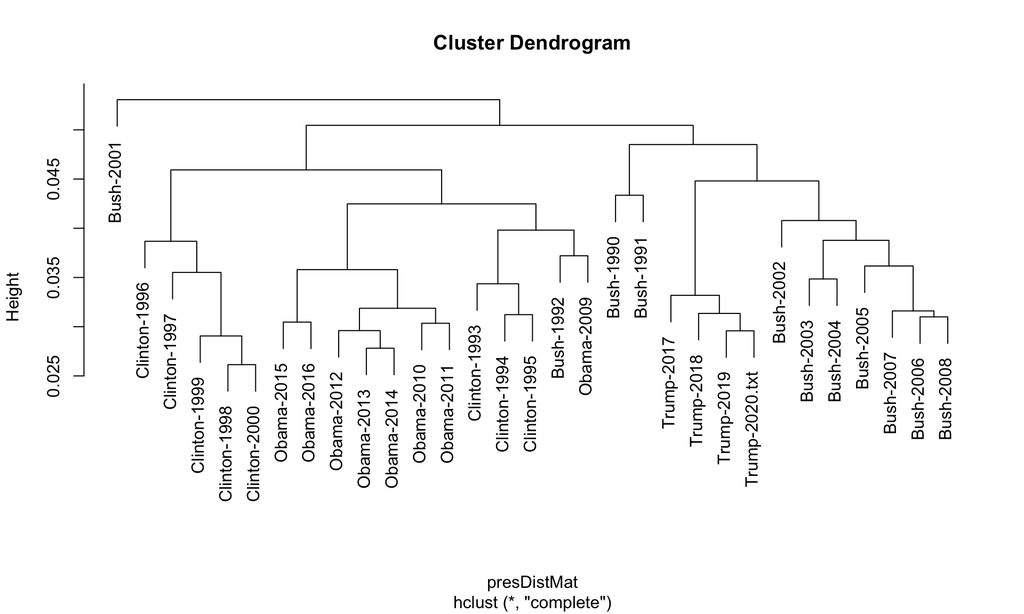

```r
# hiarchical clustering the distance object
presCluster <- hclust(presDistMat)

# plot as a dendrogram
plot(presCluster, labels = docnames(presDfm))
```

O podríamos mirar **agrupamiento de términos** en su lugar:

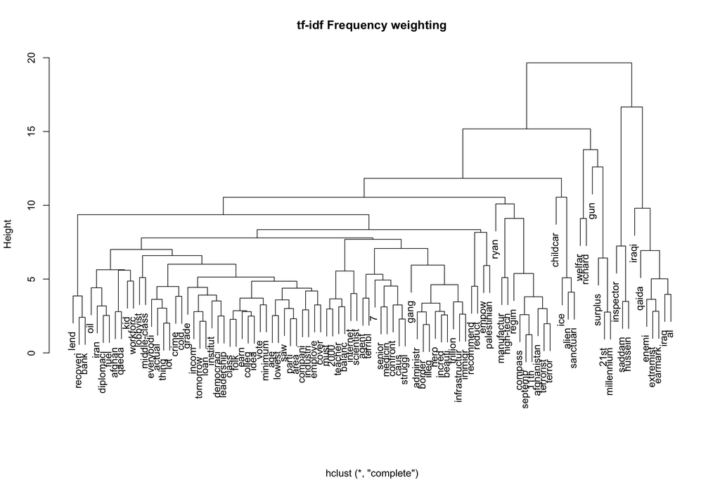

```r
# word dendrogram with tf-idf weighting
wordDfm <- dfm_sort(dfm_tfidf(presDfm))
wordDfm <- t(wordDfm)[1:100,]  # because transposed
wordDistMat <- dist(wordDfm)
wordCluster <- hclust(wordDistMat)
plot(wordCluster, xlab = "", main = "tf-idf Frequency weighting")
```